# Overmodification Experiment 2: Processing Script (Version 2.0)

A processing script for experiment two of the overmodification project

*Set up computing environment*

```r
library(tidyverse)
library(jsonlite)
library(brms)
library(tidybayes)
library(BayesFactor)
library(ggthemr)
ggthemr("pale")


sand = c("#e0cda9")
dust = c("#9E8472")
forest = c("#a0ae9b")
shallowWaters = c("#a4b8c1")

darkSand = c("#5C4033")
darkDust = c("#1b0000")
darkForest = c("#06402B")
darkShallowWaters = c("#2f4858")

earthShades = c("#b2988e", "#b37a5f", "#d4b88a", "#a0ae9b", "#8d9da8")

earthShadesDark = c("#554740", "#553929", "#68553d", "#06402B", "#2f4858")

fourPalette = c("#7a6b6e", "#8d9da8", "#e0cda9", "#a8a89e")

fourPaletteDark = c("#1b0000", "#2f4858", "#5C4033", "#06402B")

threePalette = c("#8d9da8", "#a8a89e", "#e0cda9")

threePaletteDark = c("#2f4858", "#06402B", "#5C4033")

data <- read_csv("data/rawData.csv")

finishStatusOrient <- read_csv("data/orientationFinishStatuses.csv")
finishStatusColorLoFreq <- read_csv("data/colorLoFreqFinishStatuses.csv")
finishStatusColorHiFreq <- read_csv("data/colorHiFreqFinishStatuses.csv")


#for ease of col name use
colnames(data)<- c("serverCode", "column1", "column2", "string")
```

*Removing participants who did not complete the experiment (in-line with ethics approval), and experimenters debug link*

```r
# experimenters debugging
data <- data %>%
  select(-column1) %>%
  filter(!grepl('debug', serverCode)) %>%
  separate(
    serverCode,
    into = c("Participant id", NA),
    sep = ":",
    remove=FALSE
    )

# drop outs
finishStatus <- bind_rows(finishStatusOrient, finishStatusColorLoFreq, finishStatusColorHiFreq)

data <- finishStatus %>%
  select("Participant id", "Status") %>%
  left_join(data) %>%
  filter(Status == "APPROVED") %>%
  select(-`Participant id`, -Status)
```

## Transforming JSON strings to nice tibbles

*Turn server codes into participants with id’s, and filter out unnecessary columns.*

```r
participantData <- data %>%
  separate(serverCode,
           into = c("participant", NA),
           sep = ":",
           remove=FALSE) %>%
  group_by(participant) %>%
  mutate(participant = if(n() > 1) {
    sprintf("participant%03d",
            cur_group_id())
    }) %>%
  ungroup() %>%
  select(participant,
         everything(),
         -serverCode) %>%
  arrange(participant) %>%
  select(-column2)
```

*Check our total N*

```r
usablePreEverything <- participantData$participant %>%
  unique()

message('Everything including rejections and returns: ', length(usablePreEverything), ' people.')
```

As expected, 60 participants.

*Filter in relevant data*

```r
data <- participantData %>%
  filter(str_detect(tolower(string), "setsize") |
         str_detect(tolower(string), "condition"))
```

*Parse, and also removing full trial here, to take the data we need.*

```r
parseddata <- data %>%
  mutate(inx = 1:n()) %>%
  rowwise() %>%
  mutate(trialdata = lapply(string, fromJSON)) %>%
  unnest(trialdata) %>%
  mutate(label = names(trialdata)) %>%
  spread(label, trialdata) %>%
  # remove full trial
  select(-fullTrial) %>%
  unnest(where(is.list)) %>%
  select(-string, -inx)
```

*Demarcate participants in low freq condition*

```r
# Assuming you have a participant identifier column like "participantID"
# First, identify which participants have the "nonFreqColorTerms" condition
nonFreqParticipants <- parseddata %>%
  filter(condition == "nonFreqColorTerms") %>%
  distinct(participant) %>%
  pull(participant)

# Now update targetColor for all rows belonging to those participants
parseddata <- parseddata %>%
  mutate(
    targetColor = case_when(
      participant %in% nonFreqParticipants & targetColor == "blue" ~ "teal",
      participant %in% nonFreqParticipants & targetColor == "green" ~ "jade",
      TRUE ~ targetColor
    )
  )
```

*Make low freq redundant values change*

```r
# First, identify participants who have teal or jade target colors
participants_with_low_freq_colors <- parseddata %>%
  filter(targetColor %in% c("teal", "jade")) %>%
  distinct(participant) %>%
  pull(participant)

# Update redundant column for all rows belonging to those participants
parseddata <- parseddata %>%
  mutate(
    redundant = case_when(
      participant %in% participants_with_low_freq_colors ~ "colorredundantlowfreq",
      TRUE ~ redundant
    )
  )

# remove condition column
parseddata <- parseddata %>%
  select(-condition)
```

*Save the dataframe*

```r
write_csv(parseddata, "data/parsedDataFrame.csv")
```

*Check our total N recruited after filtering in relevant data*

```r
usableAfterFirstFilter <- parseddata$participant %>%
  unique()

message('Total recruited is: ', length(usableAfterFirstFilter), ' people.')
```

N still at 60, as it should be.

## Participant Removal

There is just one applicable criteria here: accuracy. Whether the noun used matches the actual shape.

*Filter in crit data*

```r
parsedCrit <- parseddata %>%
  filter(
    trialType == "crit"
  )
```

*Mutate accuracy*

```r
accuracyParsedCrit <- parsedCrit %>%
  mutate(accurate = str_detect(response, fixed(targetShape)))
```

*Check for unacceptable participants (>50% as pre-registered)*

```r
participantAccuracy <- accuracyParsedCrit %>%
  group_by(participant) %>%
  summarise(
    total_trials = n(),
    false_trials = sum(accurate == FALSE, na.rm = TRUE),
    proportion_false = false_trials / total_trials
  ) %>%
  filter(proportion_false > 0.5) %>% view()
```

No removals! Woohoo!

*Compute n-trials with inaccuracies*

```r
inaccurateTrials <- accuracyParsedCrit %>%
  filter(accurate == FALSE)

# n trials removed
nrow(inaccurateTrials)
```

```
[1] 44
```

```r
# % trials removed
nrow(inaccurateTrials) / nrow(accuracyParsedCrit)
```

```
[1] 0.02158979
```

*Filter out the rest of inaccuracies via individual trials, and remove accurate because we don’t need it.*

```r
parsedcrit <- accuracyParsedCrit %>%
  filter(accurate == TRUE) %>%
  select(-accurate)
```

#### Taking stock

```r
usableAfterExclusions <- parsedcrit$participant %>%
  unique()

usableTrials <- nrow(parsedcrit)

message('Total participants analysed: ', length(usableAfterFirstFilter), ' people.')

message('Total number of critical trials: ', usableTrials)
```

And that’s it! Hard to believe after the hell of the last experiment.

## Building the Final Tibble

*Create overinformativeness*

```r
nouns <- c("circle", "square", "hexagon", "pentagon")
```

*Create overinformativeness column as any response with more than the nouns*

```r
process_response <- function(response) {
  words <- str_split(tolower(response), "\\s+")[[1]]
  nonNounCount <- sum(!words %in% nouns & words != "")
  return(nonNounCount)
}

tibble <- parsedcrit %>%
  mutate(across(where(is.character), tolower)) %>%
  rowwise() %>%
  mutate(
    nonNounCount = process_response(response),
    overinformative = nonNounCount >= 1
  ) %>%
  select(-nonNounCount) %>%
  ungroup()
```

*Manual Check*

```r
tibble %>%
  select(overinformative, response)
```

```
# A tibble: 1,994 × 2
   overinformative response
   <lgl>           <chr>
 1 TRUE            blue hexagon
 2 FALSE           square
 3 FALSE           hexagon
 4 FALSE           square
 5 TRUE            blue pentagon
 6 FALSE           hexagon
 7 FALSE           circle
 8 FALSE           hexagon
 9 FALSE           pentagon
10 FALSE           pentagon
# ℹ 1,984 more rows
```

*Rename for plotting and working with df*

```r
tibble <- tibble %>%
    mutate(setSize = recode(setSize, setsize3 = 'setsize03')) %>%
  mutate(setSize = recode(setSize, setsize6 = 'setsize06')) %>%
  mutate(setSize = recode(setSize, setsize9 = 'setsize09'))
```

## Whaddowegot?

*Colour vs. Orientation Redundant*

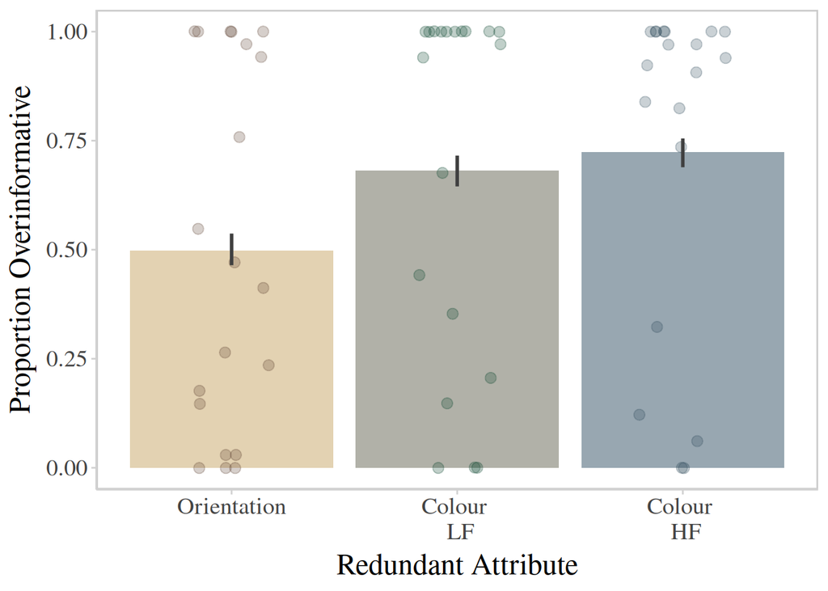

```r
tibble %>%
  filter(trialType == "crit") %>%
  mutate(od = ifelse(overinformative, 1, 0)) %>%
  ggplot(
    aes(x = redundant,
        y = od,
        fill = redundant,
        color = redundant)
    ) +
  stat_summary(fun.y = mean, geom="bar",
               alpha = 0.9, show.legend=FALSE,
               color = NA) +
  geom_jitter(
      stat = "summary", aes(group = participant),
      fun = mean, alpha = 0.25, size = 2.8,
      show.legend = FALSE, width = 0.2
      ) +
  stat_summary(fun.data = mean_cl_boot,
               geom="linerange", size = 1,
               color = "grey25") +
  coord_cartesian(ylim = c(0, 1)) +
  ylab("Proportion Overinformative") +
  xlab("Redundant Attribute") +
  theme(
    text = element_text(size = 18,
                        family = "serif",
                        color = "black"),
    panel.border = element_rect(color = "gray80",
                                fill = NA,
                                size = 1),
    panel.grid = element_blank()
    ) +
 scale_x_discrete(
    limits = c("orientredundant", "colorredundantlowfreq", "colorredundant"),

    labels = c("Orientation",  "Colour \n LF", "Colour \n HF")
 ) +
  scale_fill_manual(values = threePalette) +
  scale_color_manual(values = threePaletteDark)
```

*Comparison of set sizes, faceted by redundant attribute*

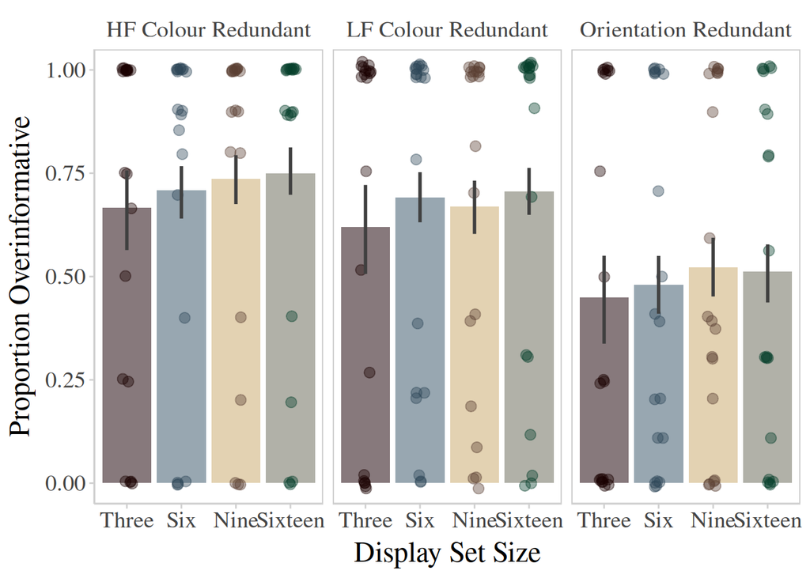

```r
labels <- c(
  "colorredundant" = "HF Colour Redundant",
  "colorredundantlowfreq" = "LF Colour Redundant",
  "orientredundant" = "Orientation Redundant"
)

tibble %>%
  mutate(od = ifelse(overinformative, 1, 0)) %>%
  filter(trialType == "crit") %>%
  ggplot(
    aes(x = setSize,
        y = od,
        fill = setSize,
        color = setSize)
    ) +
  facet_wrap(~redundant,
             labeller = as_labeller(labels)
               ) +
  stat_summary(fun.y = mean, geom="bar",
               alpha = 0.9, show.legend=FALSE,
               color = NA) +
  geom_jitter(
      stat = "summary", aes(group = participant),
      fun = mean, alpha = 0.4, size = 2.8,
      show.legend = FALSE, width = 0.1
      ) +
  stat_summary(fun.data = mean_cl_boot,
               geom="linerange", size = 1,
               color = "grey25") +
  coord_cartesian(ylim = c(0, 1)) +
  ylab("Proportion Overinformative") +
  xlab("Display Set Size") +
  theme(
    text = element_text(size = 18,
                        family = "serif",
                        color = "black"),
    panel.border = element_rect(color = "gray80",
                                fill = NA,
                                size = 0.7),
    panel.grid = element_blank()
    ) +
  scale_fill_manual(values = fourPalette
                    ) +
  scale_color_manual(values = fourPaletteDark
                     ) +
  scale_x_discrete(
    labels = c("Three", "Six", "Nine", "Sixteen")
    )
```

*Comparison of n-distractors, faceted by redundant attribute*

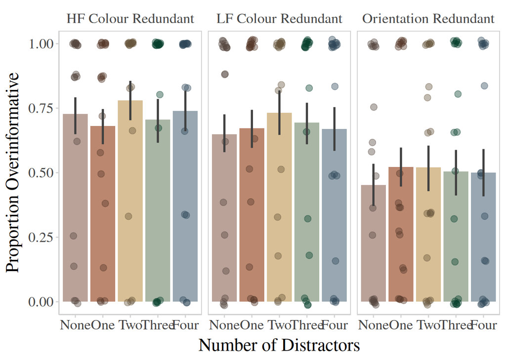

```r
labels <- c(
  "colorredundant" = "HF Colour Redundant",
  "colorredundantlowfreq" = "LF Colour Redundant",
  "orientredundant" = "Orientation Redundant"
)

tibble %>%
  mutate(od = ifelse(overinformative, 1, 0)) %>%
  filter(trialType == "crit") %>%
  ggplot(
    aes(x = nDistract,
        y = od,
        fill = nDistract,
        color = nDistract)
    ) +
  facet_wrap(~redundant,
             labeller = as_labeller(labels)
               ) +
  stat_summary(fun.y = mean, geom="bar",
               alpha = 0.9, show.legend=FALSE,
               color = NA) +
  geom_jitter(
      stat = "summary", aes(group = participant),
      fun = mean, alpha = 0.4, size = 2.8,
      show.legend = FALSE, width = 0.1
      ) +
  stat_summary(fun.data = mean_cl_boot,
               geom="linerange", size = 1,
               color = "grey25") +
  coord_cartesian(ylim = c(0, 1)) +
  ylab("Proportion Overinformative") +
  xlab("Number of Distractors") +
  theme(
    text = element_text(size = 18,
                        family = "serif",
                        color = "black"),
    panel.border = element_rect(color = "gray80",
                                fill = NA,
                                size = 0.7),
    panel.grid = element_blank()
    ) +
  scale_fill_manual(values = earthShades) +
  scale_color_manual(values = earthShadesDark) +
  scale_x_discrete(
    labels = c("None", "One", "Two", "Three", "Four")
    )
```

## Inferential Statistics

### Null

*Set up*

```r
null <- brm(
  formula = overinformative ~ 1,
  data = tibble,
  family = bernoulli(link = "logit"), #binary logistic regression
  warmup = 5000,  #burn-in
  iter = 10000,  #samples
  chains = 4,  #n chains
  cores=4, # cpu cores running in parallel
  #prior = prior("normal(0, 2)", class = "b"),
  seed = 3000, #seed so we can return
  save_pars = save_pars(all = TRUE)
  )
```

*Summary*

```r
summary(null)
```

```
 Family: bernoulli
  Links: mu = logit
Formula: overinformative ~ 1
   Data: tibble (Number of observations: 1994)
  Draws: 4 chains, each with iter = 10000; warmup = 5000; thin = 1;
         total post-warmup draws = 20000

Regression Coefficients:
          Estimate Est.Error l-95% CI u-95% CI Rhat Bulk_ESS Tail_ESS
Intercept     0.55      0.05     0.46     0.64 1.00     7988     9370

Draws were sampled using sampling(NUTS). For each parameter, Bulk_ESS
and Tail_ESS are effective sample size measures, and Rhat is the potential
scale reduction factor on split chains (at convergence, Rhat = 1).
```

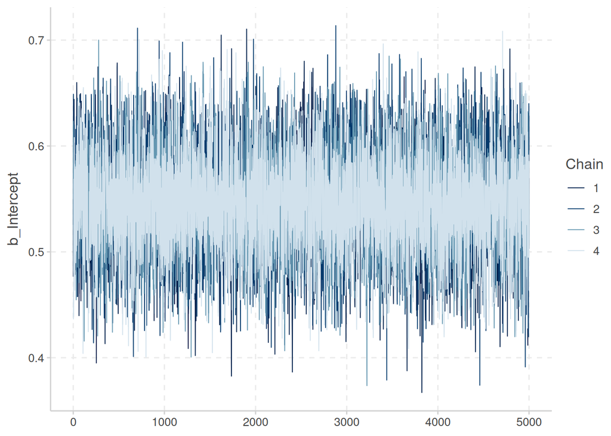

```r
# chain convergence
mcmc_plot(null,
         type = "trace",
         prob = 0.95)
```

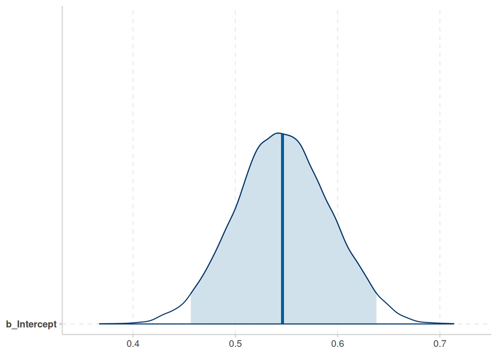

```r
# point estimate visualisation
mcmc_plot(null,
         type = "areas",
         prob = 0.95)
```

### Full Model

*Set-up*

```r
full <- brm(
  formula = overinformative ~ 1 + redundant + nDistract + setSize,
  data = tibble,
  family = bernoulli(link = "logit"), #binary logistic regression
  warmup = 5000,  #burn-in
  iter = 10000,  #samples
  chains = 4,  #n chains
  cores=4, # cpu cores running in parallel
  prior = prior("normal(0, 2)", class = "b"),
  seed = 3000, #seed so we can return
  save_pars = save_pars(all = TRUE)
  )
```

*Summary*

```r
summary(full)
```

```
 Family: bernoulli
  Links: mu = logit
Formula: overinformative ~ 1 + redundant + nDistract + setSize
   Data: tibble (Number of observations: 1994)
  Draws: 4 chains, each with iter = 10000; warmup = 5000; thin = 1;
         total post-warmup draws = 20000

Regression Coefficients:
                               Estimate Est.Error l-95% CI u-95% CI Rhat
Intercept                          0.69      0.17     0.36     1.02 1.00
redundantcolorredundantlowfreq    -0.20      0.12    -0.44     0.03 1.00
redundantorientredundant          -0.98      0.12    -1.20    -0.75 1.00
nDistractdistractors1              0.07      0.14    -0.19     0.34 1.00
nDistractdistractors2              0.25      0.16    -0.06     0.55 1.00
nDistractdistractors3              0.05      0.15    -0.24     0.36 1.00
nDistractdistractors4              0.06      0.15    -0.24     0.36 1.00
setSizesetsize06                   0.16      0.17    -0.18     0.49 1.00
setSizesetsize09                   0.23      0.17    -0.10     0.57 1.00
setSizesetsize16                   0.29      0.17    -0.05     0.63 1.00
                               Bulk_ESS Tail_ESS
Intercept                         12472    12747
redundantcolorredundantlowfreq    15920    15122
redundantorientredundant          16343    15656
nDistractdistractors1             14543    15419
nDistractdistractors2             14181    14812
nDistractdistractors3             13471    14612
nDistractdistractors4             13472    14578
setSizesetsize06                  10621    13847
setSizesetsize09                  10819    13714
setSizesetsize16                  10542    14128

Draws were sampled using sampling(NUTS). For each parameter, Bulk_ESS
and Tail_ESS are effective sample size measures, and Rhat is the potential
scale reduction factor on split chains (at convergence, Rhat = 1).
```

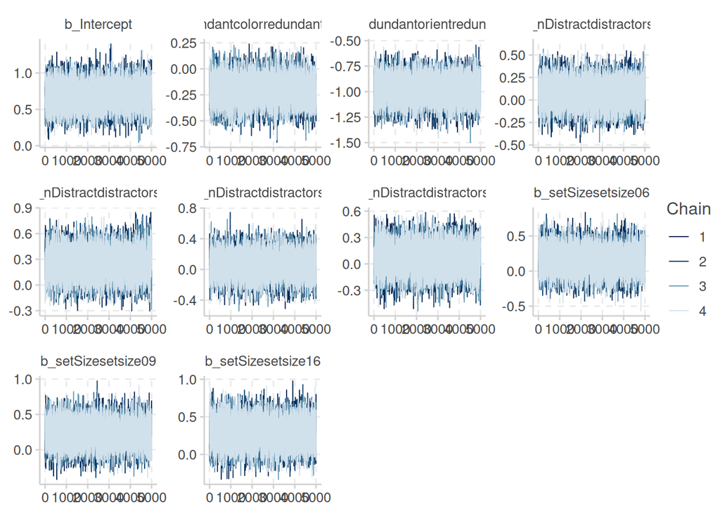

```r
# chain convergence
mcmc_plot(full,
         type = "trace",
         prob = 0.95)
```

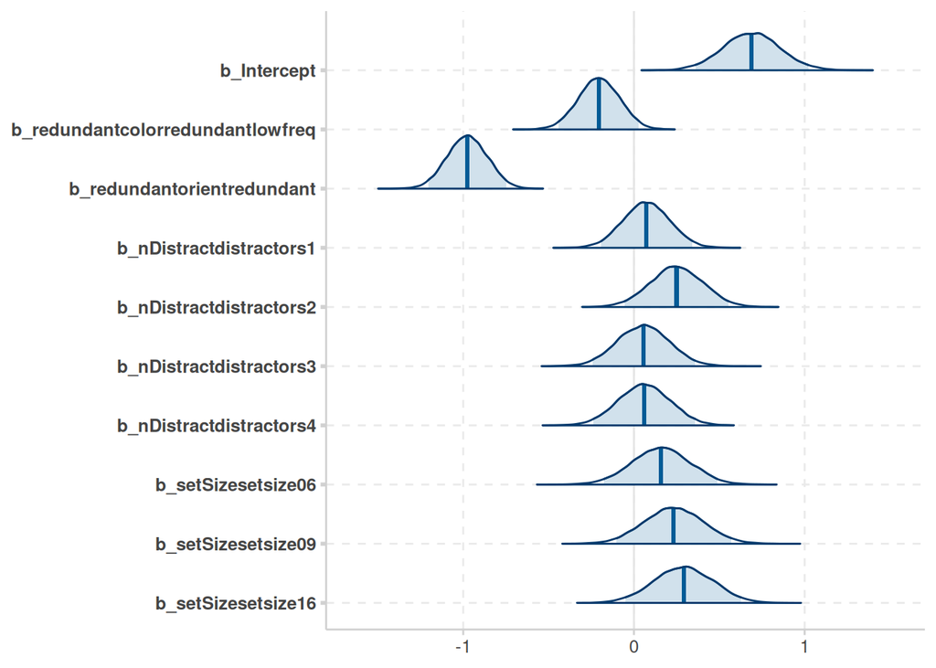

```r
# point estimate visualisation
mcmc_plot(full,
         type = "areas",
         prob = 0.95)
```

### Setsize + Attribute-redundant

*Set up*

```r
SetAtt  <- brm(
  formula = overinformative ~ 1 + redundant + setSize,
  data = tibble,
  family = bernoulli(link = "logit"), #binary logistic regression
  warmup = 5000,  #burn-in
  iter = 10000,  #samples
  chains = 4,  #n chains
  cores=4, # cpu cores running in parallel
  prior = prior("normal(0, 2)", class = "b"),
  seed = 3000, #seed so we can return
  save_pars = save_pars(all = TRUE)
  )
```

*Summary*

```r
summary(SetAtt)
```

```
 Family: bernoulli
  Links: mu = logit
Formula: overinformative ~ 1 + redundant + setSize
   Data: tibble (Number of observations: 1994)
  Draws: 4 chains, each with iter = 10000; warmup = 5000; thin = 1;
         total post-warmup draws = 20000

Regression Coefficients:
                               Estimate Est.Error l-95% CI u-95% CI Rhat
Intercept                          0.73      0.15     0.43     1.03 1.00
redundantcolorredundantlowfreq    -0.20      0.12    -0.44     0.03 1.00
redundantorientredundant          -0.97      0.12    -1.21    -0.74 1.00
setSizesetsize06                   0.20      0.16    -0.11     0.51 1.00
setSizesetsize09                   0.28      0.16    -0.04     0.59 1.00
setSizesetsize16                   0.34      0.16     0.03     0.64 1.00
                               Bulk_ESS Tail_ESS
Intercept                         11799    11751
redundantcolorredundantlowfreq    16765    13831
redundantorientredundant          17279    15007
setSizesetsize06                  12082    13419
setSizesetsize09                  11398    13399
setSizesetsize16                  11921    12800

Draws were sampled using sampling(NUTS). For each parameter, Bulk_ESS
and Tail_ESS are effective sample size measures, and Rhat is the potential
scale reduction factor on split chains (at convergence, Rhat = 1).
```

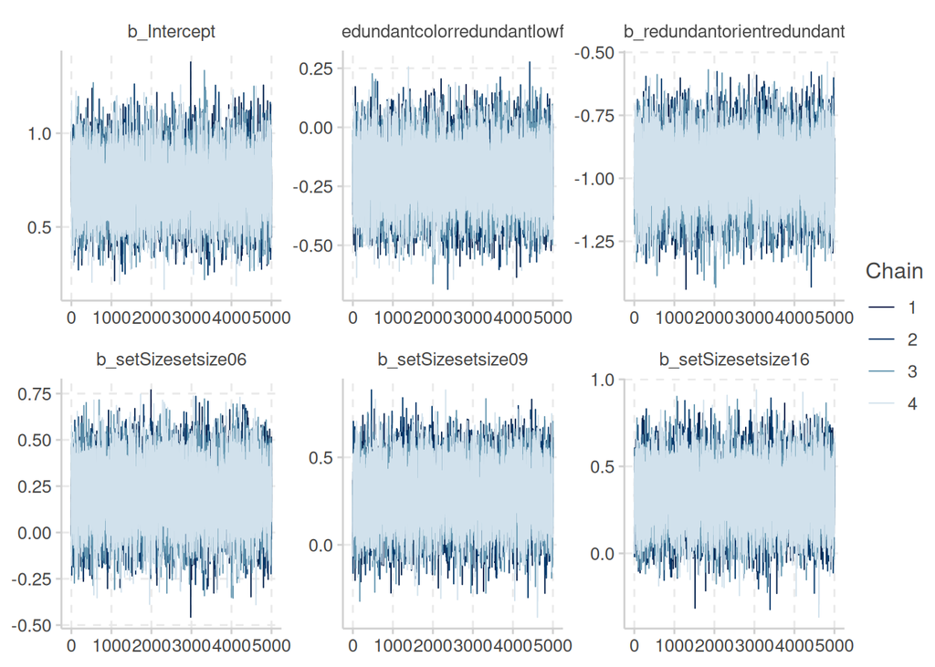

```r
# chain convergence
mcmc_plot(SetAtt,
         type = "trace",
         prob = 0.95)
```

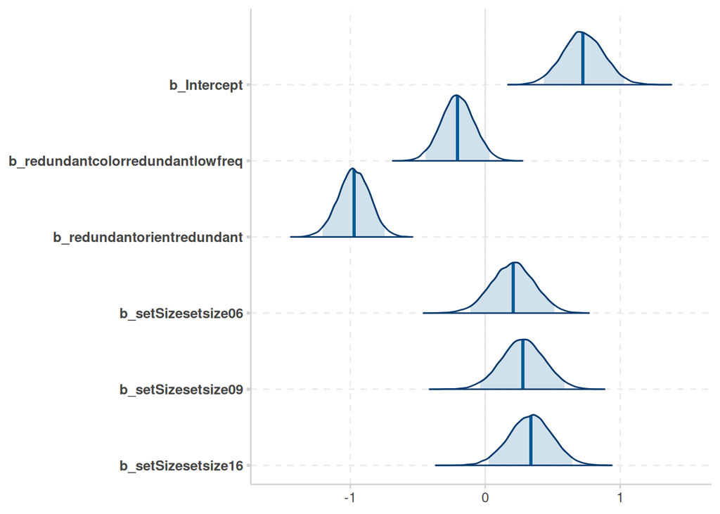

```r
# point estimate visualisation
mcmc_plot(SetAtt,
         type = "areas",
         prob = 0.95)
```

### N-distractors + Attribute-redundant

*Set up*

```r
DistAtt  <- brm(
  formula = overinformative ~ 1 + redundant + nDistract,
  data = tibble,
  family = bernoulli(link = "logit"), #binary logistic regression
  warmup = 5000,  #burn-in
  iter = 10000,  #samples
  chains = 4,  #n chains
  cores=4, # cpu cores running in parallel
  prior = prior("normal(0, 2)", class = "b"),
  seed = 3000, #seed so we can return
  save_pars = save_pars(all = TRUE)
  )
```

*Summary*

```r
summary(DistAtt)
```

```
 Family: bernoulli
  Links: mu = logit
Formula: overinformative ~ 1 + redundant + nDistract
   Data: tibble (Number of observations: 1994)
  Draws: 4 chains, each with iter = 10000; warmup = 5000; thin = 1;
         total post-warmup draws = 20000

Regression Coefficients:
                               Estimate Est.Error l-95% CI u-95% CI Rhat
Intercept                          0.86      0.12     0.62     1.09 1.00
redundantcolorredundantlowfreq    -0.20      0.12    -0.44     0.03 1.00
redundantorientredundant          -0.97      0.12    -1.20    -0.75 1.00
nDistractdistractors1              0.07      0.14    -0.20     0.34 1.00
nDistractdistractors2              0.31      0.15     0.02     0.60 1.00
nDistractdistractors3              0.11      0.15    -0.18     0.41 1.00
nDistractdistractors4              0.12      0.15    -0.18     0.41 1.00
                               Bulk_ESS Tail_ESS
Intercept                         17696    13530
redundantcolorredundantlowfreq    22579    16470
redundantorientredundant          22940    17062
nDistractdistractors1             17776    16514
nDistractdistractors2             18366    16331
nDistractdistractors3             19189    16410
nDistractdistractors4             18799    16701

Draws were sampled using sampling(NUTS). For each parameter, Bulk_ESS
and Tail_ESS are effective sample size measures, and Rhat is the potential
scale reduction factor on split chains (at convergence, Rhat = 1).
```

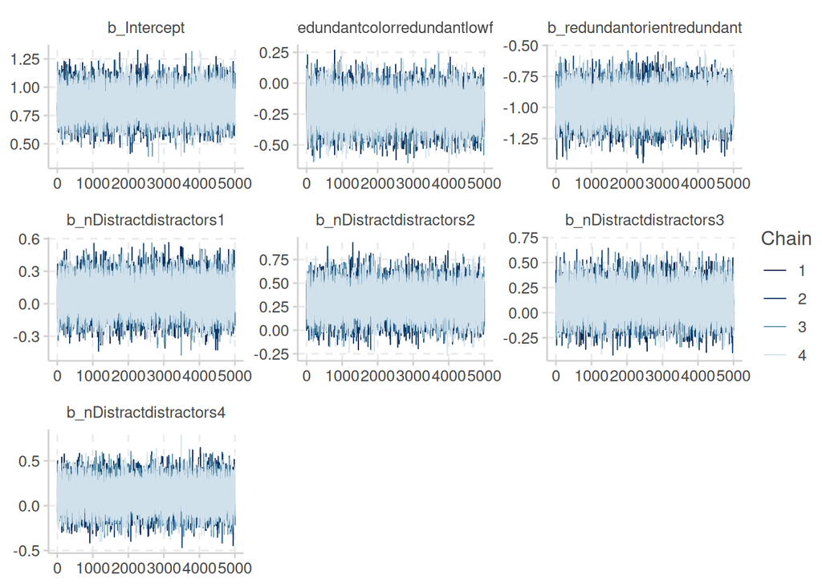

```r
# chain convergence
mcmc_plot(DistAtt,
         type = "trace",
         prob = 0.95)
```

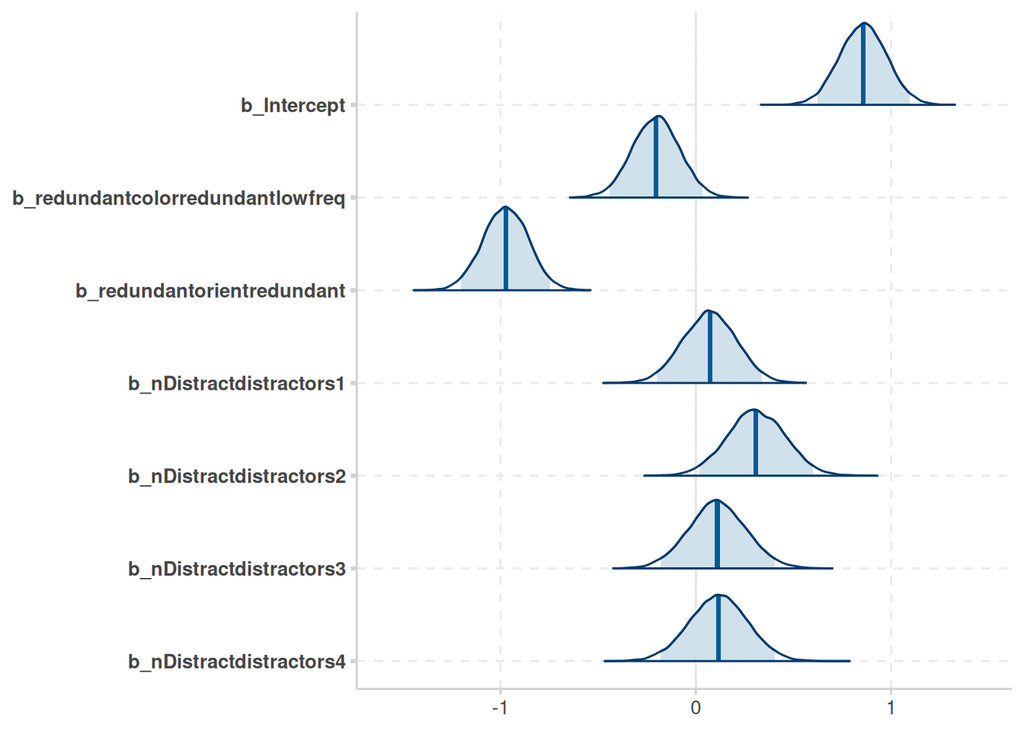

```r
# point estimate visualisation
mcmc_plot(DistAtt,
         type = "areas",
         prob = 0.95)
```

### Set Size

*Set up*

```r
setSize  <- brm(
  formula = overinformative ~ 1 + setSize,
  data = tibble,
  family = bernoulli(link = "logit"), #binary logistic regression
  warmup = 5000,  #burn-in
  iter = 10000,  #samples
  chains = 4,  #n chains
  cores=4, # cpu cores running in parallel
  prior = prior("normal(0, 2)", class = "b"),
  seed = 3000, #seed so we can return
  save_pars = save_pars(all = TRUE)
  )
```

*Summary*

```r
summary(setSize)
```

```
 Family: bernoulli
  Links: mu = logit
Formula: overinformative ~ 1 + setSize
   Data: tibble (Number of observations: 1994)
  Draws: 4 chains, each with iter = 10000; warmup = 5000; thin = 1;
         total post-warmup draws = 20000

Regression Coefficients:
                 Estimate Est.Error l-95% CI u-95% CI Rhat Bulk_ESS Tail_ESS
Intercept            0.32      0.13     0.06     0.58 1.00     8132     9431
setSizesetsize06     0.19      0.16    -0.12     0.50 1.00     9175    11116
setSizesetsize09     0.27      0.16    -0.04     0.57 1.00     9093    10579
setSizesetsize16     0.32      0.16     0.01     0.63 1.00     9041    10796

Draws were sampled using sampling(NUTS). For each parameter, Bulk_ESS
and Tail_ESS are effective sample size measures, and Rhat is the potential
scale reduction factor on split chains (at convergence, Rhat = 1).
```

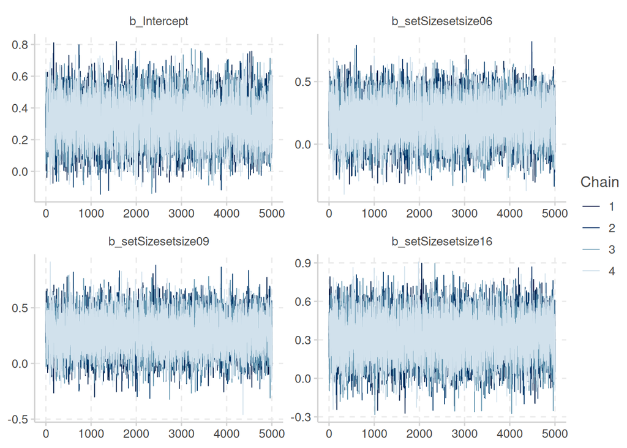

```r
# chain convergence
mcmc_plot(setSize,
         type = "trace",
         prob = 0.95)
```

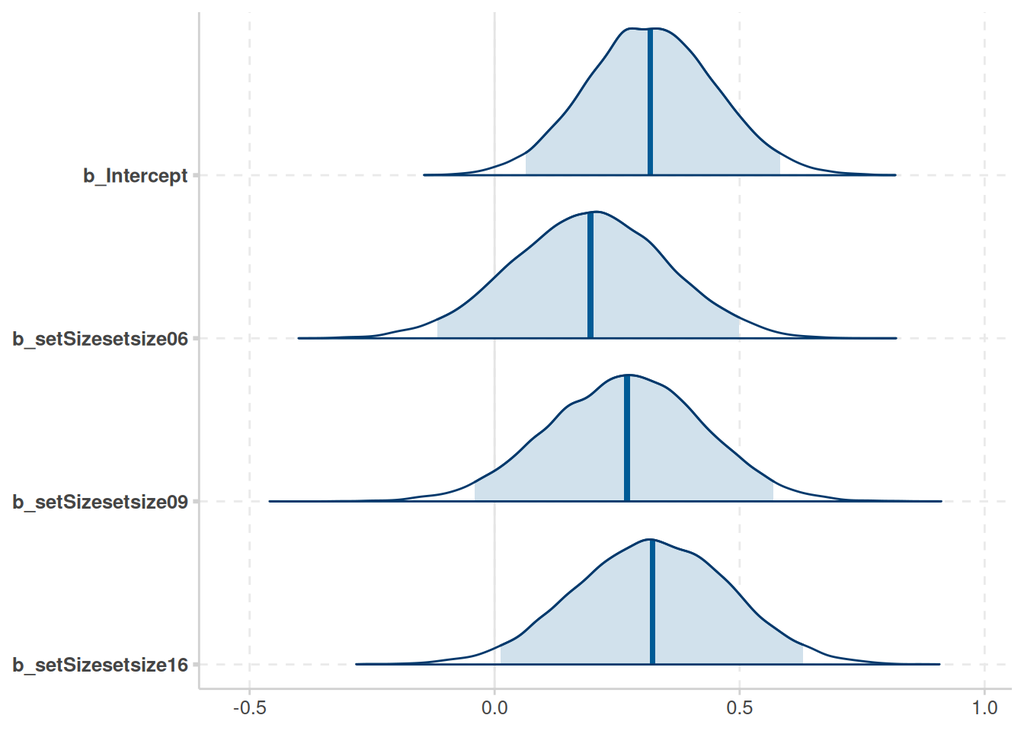

```r
# point estimate visualisation
mcmc_plot(setSize,
         type = "areas",
         prob = 0.95)
```

### N distractors

*Set up*

```r
nDistractor  <- brm(
  formula = overinformative ~ 1 + nDistract,
  data = tibble,
  family = bernoulli(link = "logit"), #binary logistic regression
  warmup = 5000,  #burn-in
  iter = 10000,  #samples
  chains = 4,  #n chains
  cores=4, # cpu cores running in parallel
  prior = prior("normal(0, 2)", class = "b"),
  seed = 3000, #seed so we can return
  save_pars = save_pars(all = TRUE)
  )
```

*Summary*

```r
summary(nDistractor)
```

```
 Family: bernoulli
  Links: mu = logit
Formula: overinformative ~ 1 + nDistract
   Data: tibble (Number of observations: 1994)
  Draws: 4 chains, each with iter = 10000; warmup = 5000; thin = 1;
         total post-warmup draws = 20000

Regression Coefficients:
                      Estimate Est.Error l-95% CI u-95% CI Rhat Bulk_ESS
Intercept                 0.44      0.09     0.26     0.63 1.00    12571
nDistractdistractors1     0.07      0.13    -0.19     0.32 1.00    15073
nDistractdistractors2     0.30      0.15     0.01     0.59 1.00    14554
nDistractdistractors3     0.11      0.15    -0.18     0.39 1.00    15481
nDistractdistractors4     0.11      0.14    -0.17     0.39 1.00    15909
                      Tail_ESS
Intercept                12571
nDistractdistractors1    15500
nDistractdistractors2    14797
nDistractdistractors3    15437
nDistractdistractors4    16118

Draws were sampled using sampling(NUTS). For each parameter, Bulk_ESS
and Tail_ESS are effective sample size measures, and Rhat is the potential
scale reduction factor on split chains (at convergence, Rhat = 1).
```

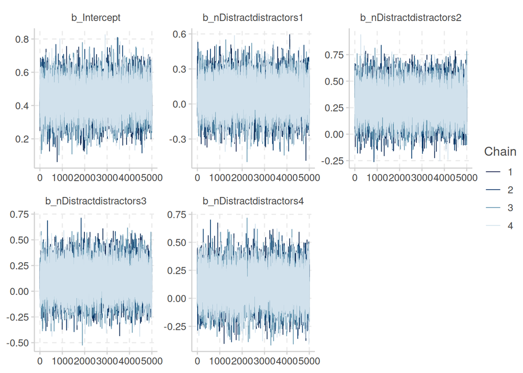

```r
# chain convergence
mcmc_plot(nDistractor,
         type = "trace",
         prob = 0.95)
```

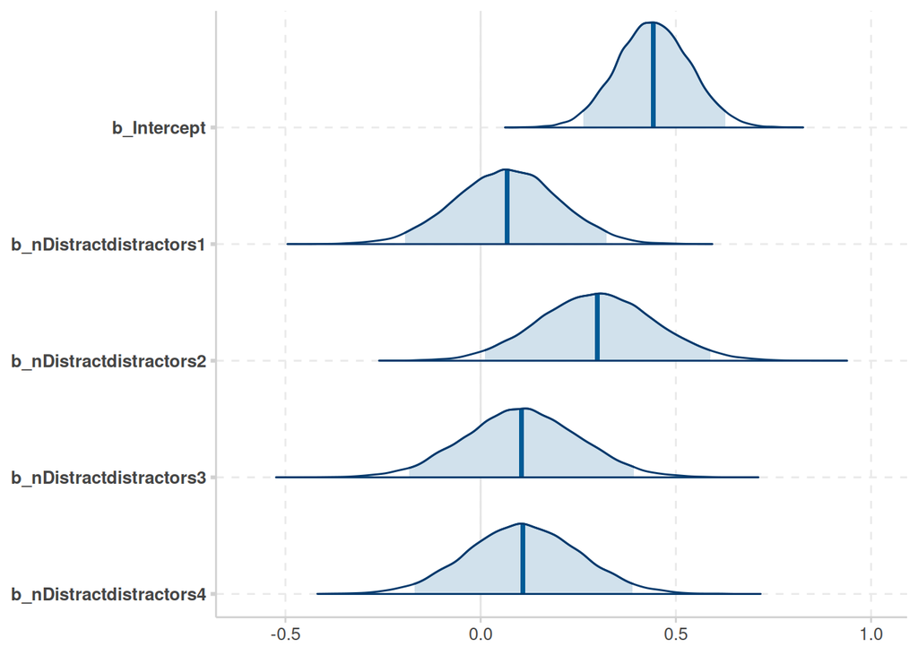

```r
# point estimate visualisation
mcmc_plot(nDistractor,
         type = "areas",
         prob = 0.95)
```

### Attribute Redundant

*Set up*

```r
attribute  <- brm(
  formula = overinformative ~ 1 + redundant,
  data = tibble,
  family = bernoulli(link = "logit"), #binary logistic  regression
  warmup = 5000,  #burn-in
  iter = 10000,  #samples
  chains = 4,  #n chains
  cores=4, # cpu cores running in parallel
  prior = prior("normal(0, 2)", class = "b"),
  seed = 3000, #seed for determinism
  save_pars = save_pars(all = TRUE)
  )
```

*Summary*

```r
summary(attribute)
```

```
 Family: bernoulli
  Links: mu = logit
Formula: overinformative ~ 1 + redundant
   Data: tibble (Number of observations: 1994)
  Draws: 4 chains, each with iter = 10000; warmup = 5000; thin = 1;
         total post-warmup draws = 20000

Regression Coefficients:
                               Estimate Est.Error l-95% CI u-95% CI Rhat
Intercept                          0.97      0.09     0.80     1.14 1.00
redundantcolorredundantlowfreq    -0.20      0.12    -0.44     0.03 1.00
redundantorientredundant          -0.97      0.12    -1.20    -0.75 1.00
                               Bulk_ESS Tail_ESS
Intercept                         11719    12140
redundantcolorredundantlowfreq    12994    13956
redundantorientredundant          13102    13149

Draws were sampled using sampling(NUTS). For each parameter, Bulk_ESS
and Tail_ESS are effective sample size measures, and Rhat is the potential
scale reduction factor on split chains (at convergence, Rhat = 1).
```

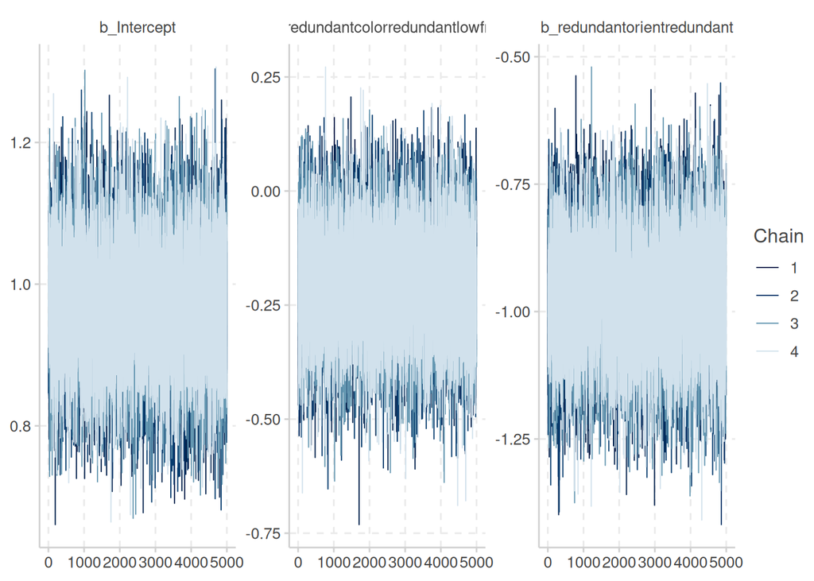

```r
# chain convergence
mcmc_plot(attribute,
         type = "trace",
         prob = 0.95)
```

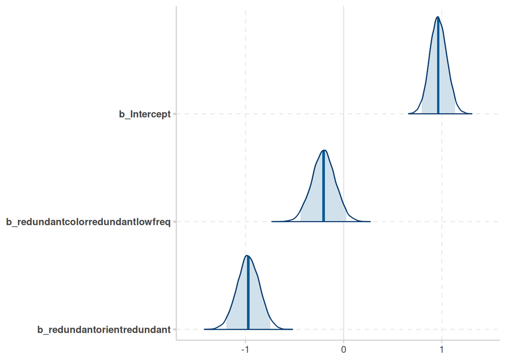

```r
# point estimate visualisation
mcmc_plot(attribute,
         type = "areas",
         prob = 0.95)
```

### Model Comparison

```r
bayes_factor(full, null, log = TRUE)
```

```
Iteration: 1
Iteration: 2
Iteration: 3
Iteration: 4
```

```
Iteration: 1
Iteration: 2
Iteration: 3
```

```
Estimated log Bayes factor in favor of full over null: 19.71456
```

```r
bayes_factor(DistAtt, null, log = TRUE)
```

```
Iteration: 1
Iteration: 2
Iteration: 3
Iteration: 4
```

```
Iteration: 1
Iteration: 2
Iteration: 3
```

```
Estimated log Bayes factor in favor of DistAtt over null: 26.36509
```

```r
bayes_factor(SetAtt, null, log = TRUE)
```

```
Iteration: 1
Iteration: 2
Iteration: 3
Iteration: 4
```

```
Iteration: 1
Iteration: 2
Iteration: 3
Iteration: 4
```

```
Estimated log Bayes factor in favor of SetAtt over null: 29.10135
```

```r
bayes_factor(setSize, null, log = TRUE)
```

```
Iteration: 1
Iteration: 2
Iteration: 3
```

```
Iteration: 1
Iteration: 2
Iteration: 3
Iteration: 4
```

```
Estimated log Bayes factor in favor of setSize over null: -6.12261
```

```r
bayes_factor(nDistractor, null, log = TRUE)
```

```
Iteration: 1
Iteration: 2
Iteration: 3
```

```
Iteration: 1
Iteration: 2
Iteration: 3
```

```
Estimated log Bayes factor in favor of nDistractor over null: -8.83425
```

```r
bayes_factor(attribute, null, log = TRUE)
```

```
Iteration: 1
Iteration: 2
Iteration: 3
Iteration: 4
```

```
Iteration: 1
Iteration: 2
Iteration: 3
Iteration: 4
```

```
Estimated log Bayes factor in favor of attribute over null: 35.05422
```